# Untitled

Gabriel Depiantti

21/10/2021

Pacotes necessários para as funções utilizadas

```r
#install.packages("tidyverse")
#install.packages("rgbif")
#install.packages("dplyr")
require(tidyverse)
require(rgbif)
```

```r
require(dplyr)
#install.packages("ggmap")
#install.packages("maps")
#install.packages("mapdata")
#install.packages('ggplot2')
require(ggplot2)
require(ggmap)
require(maps)
require(mapdata)
```

Vamos utilizar a função ‘occ_data’ para buscarmos ocorrencias no repositório do GBIF através no nome científico da especies que buscamos.Vamos utulizar os argumentos ‘hasCoordinate’ e ‘hasGeospatialIssue’ para selecionarmos apenas ocorrencias que possuem coordenadas e sem problemas geoespaciais

```r
# baixar ocorrencias
xylopea_gbif <- occ_data(scientificName = "Xylopia sericea",
                      hasCoordinate = TRUE,
                      hasGeospatialIssue=FALSE)
```

Usaremmos a função ‘dim’ para acessarmos as dimensoes do banco de dados da busca. Com ‘$data' temos as dimensões da lista de conjunto de dados que podemos ter acesso. Atraves de '$data %>% names’ podemos ver a lista com todos os data frames que podemos ter acesso.

```r
# Dimensoes do conjunto de dados
dim(xylopea_gbif$data)
```

```
## [1] 500 139
```

```r
# Lista com todos os data frames
xylopea_gbif$data %>% names
```

```
##   [1] "key"
##   [2] "scientificName"
##   [3] "decimalLatitude"
##   [4] "decimalLongitude"
##   [5] "issues"
##   [6] "datasetKey"
##   [7] "publishingOrgKey"
##   [8] "installationKey"
##   [9] "publishingCountry"
##  [10] "protocol"
##  [11] "lastCrawled"
##  [12] "lastParsed"
##  [13] "crawlId"
##  [14] "hostingOrganizationKey"
##  [15] "basisOfRecord"
```

[output cut: 124 more lines]

Com função ‘gbif_issues’ temos acesso a lista de problemas que já foram reportados e que possuem um código. Como existem muitos problemas reportados, utilizamos a função ‘strsplit’ especificar os as issues.

```r
#Problemas reportados
gbif_issues()
```

```
##           code                                             issue
## 1          bri                           BASIS_OF_RECORD_INVALID
## 2          ccm                        CONTINENT_COUNTRY_MISMATCH
## 3          cdc                CONTINENT_DERIVED_FROM_COORDINATES
## 4        conti                                 CONTINENT_INVALID
## 5         cdiv                                COORDINATE_INVALID
## 6        cdout                           COORDINATE_OUT_OF_RANGE
## 7        cdrep                            COORDINATE_REPROJECTED
## 8       cdrepf                    COORDINATE_REPROJECTION_FAILED
## 9       cdreps                COORDINATE_REPROJECTION_SUSPICIOUS
## 10     cdround                                COORDINATE_ROUNDED
## 11     cucdmis                       COUNTRY_COORDINATE_MISMATCH
## 12        cudc                  COUNTRY_DERIVED_FROM_COORDINATES
## 13        cuiv                                   COUNTRY_INVALID
## 14         cum                                  COUNTRY_MISMATCH
```

[output cut: 285 more lines]

```r
issues_gbif<-xylopea_gbif$data$issues %>%
    unique() %>%
    strsplit(.,'[,]') %>%
    unlist()
```

Problemas reportados

Agora vamos selecionar variaveis que estejam relacionadas a especies escolhida e que vão validar os dados em futuras analises.

```r
xylopea_gbif1 <- xylopea_gbif$data %>%
    dplyr::select(scientificName, acceptedScientificName,
                  decimalLatitude, decimalLongitude,issues, basisOfRecord,
                  occurrenceStatus, rightsHolder, datasetName,
                  recordedBy, locality, habitat)
```

```r
xylopea_gbif1 <- xylopea_gbif1 %>%
    distinct()
```

Para sabermos os valores únicos presentes nos dados, vamos usar a função ‘unique’ em cada coluna com a função ‘lapply’

```r
# checar niveis dos fatores
lapply(xylopea_gbif1, unique)
```

```
## $scientificName
## [1] "Xylopia sericea A.St.-Hil."
##
## $acceptedScientificName
## [1] "Xylopia sericea A.St.-Hil."
##
## $decimalLatitude
##   [1] -19.686111   3.522281   3.522294   3.522678   3.531224   3.526724
##   [7]   3.530954 -18.438056 -20.626000 -18.438055  -9.704722 -20.411667
##  [13]  -9.898467   3.547792   3.550504 -19.498361 -19.498444 -20.077778
##  [19] -14.283333 -19.970556 -13.392222   7.171056   7.136083   7.153639
##  [25]   7.155556   7.148417   7.147861   7.148139 -20.304750 -18.000000
##  [31] -15.649167   3.531519   3.530989   3.522328   3.531164   3.530984
##  [37]   3.522252   3.528123   3.530814   3.531124   3.529355   3.531291
##  [43]   3.526901   3.531629   3.531156 -21.537222 -10.352094 -12.658889
```

[output cut: 992 more lines]

Problemas não reportados

```r
# investigar niveis suspeitos
xylopea_gbif1 %>%
    distinct(habitat) %>%
    pull()
```

```
##  [1] NA
##  [2] "Bosque denso alto inundable heterogeneo"
##  [3] "Bosque de galeria y/o ripario"
##  [4] "Arbustal denso"
##  [5] "BosqueGaleria"
##  [6] "Bosque húmedo tropical"
##  [7] "Beira do rio Marmelo"
##  [8] "ForÃªt ombrophile submontagnarde de plateau dÃ©gradÃ©e"
##  [9] "Floresta Atlântica."
## [10] "Terrestrial"
## [11] "Atlantic Forest"
## [12] "Caatinga sobre afloramentos rochosos."
## [13] "Floresta OmbrÃ³fila  Densa Montana."
## [14] "Bosque amazonico preandino inundable con Mauritia flexuosa, Cariniana domestica, Inga spp., y Protium spp."
## [15] "Floresta ombrÃ³fila densa sob Tabuleiro. coletas efetuadas na parcela 2 e na estrada de acesso."
## [16] "Cerrado. Plano no local. Latossolo vermelho."
## [17] "Na orla da mata"
## [18] "Mata ciliar prÃ³xima Ã  base da cachoeira. Na orla da mata"
## [19] "Cerrado, em pequena mata"
## [20] "Cerrado, em pequena mata."
## [21] "Mata de galeria. Relevo suave. Latossolo."
## [22] "Capoeirao"
## [23] "Mata de galeria. Margem direita do córrego, borda da mata."
## [24] "Bosque inundado hasta 1.5 m. con Maquira coriacea, Erythroxylon, Pouteria, Brosimum lactescens y Xylopia."
```

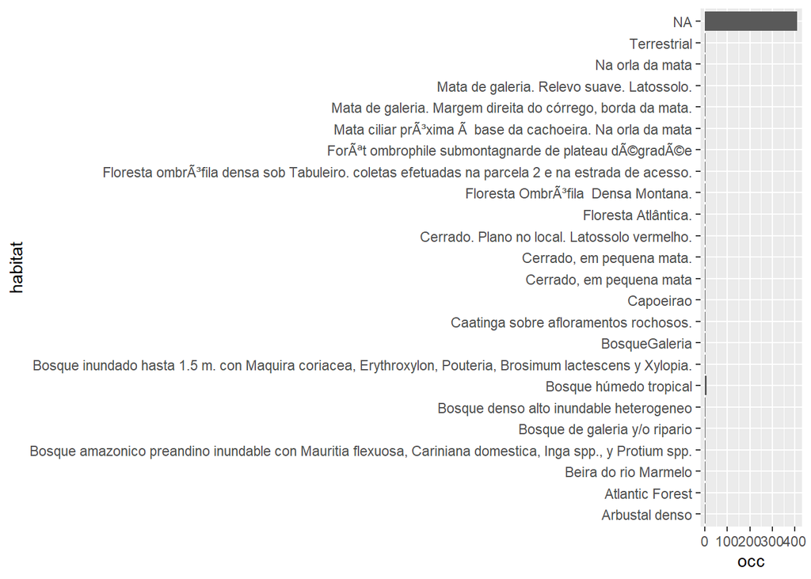

```r
# habitat
xylopea_gbif1 %>%
    group_by(habitat) %>%
    summarise(occ = length(scientificName)) %>%
    ggplot(aes(occ, y=habitat)) +
    geom_bar(stat = 'identity')
```

```r
xylopea_gbif1 %>%
    filter(locality %in% c("Floresta Atlântica.", "Capoeirao", "BosqueGaleria", "Cerrado, em pequena mata", "Terrestrial", "Atlantic Forest")) %>%
    distinct(datasetName)
```

```
## # A tibble: 0 x 1
## # ... with 1 variable: datasetName <chr>
```

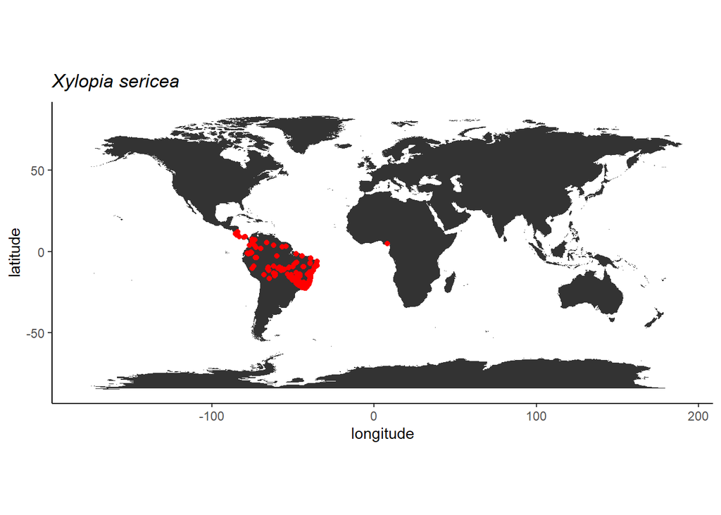

```r
world <- map_data('world')

ggplot() +
    geom_polygon(data = world, aes(x = long, y = lat, group = group)) +
    coord_fixed() +
    theme_classic() +
    geom_point(data = xylopea_gbif1, aes(x = decimalLongitude, y = decimalLatitude), color = "red") +
    labs(x = "longitude", y = "latitude", title = expression(italic("Xylopia sericea")))
```